# 제4회 중소기업 통계데이터 활용 정책아이디어 공모전 분석서

# 활용 데이터

1. 중소기업경기전망조사(2022년)
2. 장애인기업실태조사(2020년)

```python
import pandas as pd
import numpy as np
import re
import matplotlib.pyplot as plt
import seaborn as sns
sns.set_theme(style='whitegrid', font_scale=1.5)
sns.set_palette('Set2', n_colors=10)
plt.rc('font', family='malgun gothic')
plt.rc('axes', unicode_minus=False)
```

# 중소기업전망조사(2022년)

## 전처리

#### 데이터 불러오기

```python
df1 = pd.read_excel('./중소기업경기전망조사(2022년)/202201.xlsx')
df2 = pd.read_excel('./중소기업경기전망조사(2022년)/202202.xlsx')
df3 = pd.read_excel('./중소기업경기전망조사(2022년)/202203.xlsx')
df4 = pd.read_excel('./중소기업경기전망조사(2022년)/202204.xlsx')
df5 = pd.read_excel('./중소기업경기전망조사(2022년)/202205.xlsx')
df6 = pd.read_excel('./중소기업경기전망조사(2022년)/202206.xlsx')
df7 = pd.read_excel('./중소기업경기전망조사(2022년)/202207.xlsx')
df8 = pd.read_excel('./중소기업경기전망조사(2022년)/202208.xlsx')
df9 = pd.read_excel('./중소기업경기전망조사(2022년)/202209.xlsx')
df10 = pd.read_excel('./중소기업경기전망조사(2022년)/202210.xlsx')
df11 = pd.read_excel('./중소기업경기전망조사(2022년)/202211.xlsx')
df12 = pd.read_excel('./중소기업경기전망조사(2022년)/202212.xlsx')
```

#### 열 이름 바꾸기 및 병합을 위한 월 열 추가

```python
a= df1.columns
df8 = df8.rename(columns = {' x17' : 'x17'})
lst =[df1, df2, df3, df4, df5, df6, df7, df8, df9, df10, df11, df12]

for i in range(12):
    if lst[i].columns[1]== a[1]:
        lst[i] = lst[i].rename(columns={'WT':'가중치','X1':'지역', 'X2':'규모', 'X3':'산업분류', 'X16':'기업유형', 'X17_1':'수출여부', 'X17':'대기업납품여부', 'X20':'경기전반 : 금월실적', 'X21':'경기전반 : 다음달전망', 'X30' : '금월 생산', 'X31':'다음달 생산', 'X32':'금월 내수', 'X33' : '다음달 내수', 'X34':'금월 수출', 'X35':'다음달 수출', 'X36':'금월 영업이익', 'X37':'다음달 영업이익', 'X38' : '금월 자금사정', 'X39' : '다음달 자금사정', 'X40' : '금월 원자재조달', 'X41' : '다음달 원자재조달', 'X42' : '생산설비 : 이번달', 'X43':'생산설비 : 다음달', 'X44':'제품재고 : 이번달', 'X45' : '제품재고 : 다음달', 'X46': '종사자수 : 이번달', 'X47':'종사자수 : 다음달', 'X48':'생산설비 가동률 : 지난달', 'X49':'생산설비 가동률 : 이번달', 'X55':'내수부진', 'X56':'수출부진', 'X57':'판매대금회수 지연', 'X58':'자금조달 곤란', 'X59' : '업체간 과당경쟁', 'X60':'인력확보난', 'X61':'인건비 상승', 'X62' : '물류비상승 및 운송난', 'X63' : '기술경쟁력 약화', 'X64' : '제품(판매)단가하락', 'X65' : '원자재(원재료) 가격상승', 'X66':'원자재(원재료)구독난', 'X67' : '설비노후 및 부족', 'X68' : '계절적 비수기', 'X69':'환율변동', 'X70' : '고금리', 'X71' : '모기업(대기업) 불공정거래'})
    else:
        lst[i] = lst[i].rename(columns={'WT':'가중치','x1':'지역', 'x2':'규모', 'x3':'산업분류', 'x16':'기업유형', 'x17_1':'수출여부', 'x17':'대기업납품여부', 'x20':'경기전반 : 금월실적', 'x21':'경기전반 : 다음달전망', 'x30' : '금월 생산', 'x31':'다음달 생산', 'x32':'금월 내수', 'x33' : '다음달 내수', 'x34':'금월 수출', 'x35':'다음달 수출', 'x36':'금월 영업이익', 'x37':'다음달 영업이익', 'x38' : '금월 자금사정', 'x39' : '다음달 자금사정', 'x40' : '금월 원자재조달', 'x41' : '다음달 원자재조달', 'x42' : '생산설비 : 이번달', 'x43':'생산설비 : 다음달', 'x44':'제품재고 : 이번달', 'x45' : '제품재고 : 다음달', 'x46': '종사자수 : 이번달', 'x47':'종사자수 : 다음달', 'x48':'생산설비 가동률 : 지난달', 'x49':'생산설비 가동률 : 이번달', 'x55':'내수부진', 'x56':'수출부진', 'x57':'판매대금회수 지연', 'x58':'자금조달 곤란', 'x59' : '업체간 과당경쟁', 'x60':'인력확보난', 'x61':'인건비 상승', 'x62' : '물류비상승 및 운송난', 'x63' : '기술경쟁력 약화', 'x64' : '제품(판매)단가하락', 'x65' : '원자재(원재료) 가격상승', 'x66':'원자재(원재료)구독난', 'x67' : '설비노후 및 부족', 'x68' : '계절적 비수기', 'x69':'환율변동', 'x70' : '고금리', 'x71' : '모기업(대기업) 불공정거래'})
    lst[i]['월'] = i+1 #월 열 추가
```

#### 데이터 수직 병합

```python
전망조사df = pd.concat(lst, axis=0, join = 'outer').reset_index(drop=True)
```

#### 기업유형열 변경

- 일반기업 1, 벤처/이노비스/경영혁신기업 0

```python
전망조사df['기업유형'] =전망조사df['기업유형'].apply(lambda x : 0 if  x == 2 else 1)
```

#### 지역열 값 교체

```python
전망조사df['지역']=전망조사df['지역'].replace({11:'서울특별시',21:'부산광역시',22:'대구광역시', 23:'인천광역시', 24:'광주광역시', 25:'대전광역시', 26:'울산광역시', 30:'경기도(북부)',31:'경기도(남부)', 32:'강원도',33:'충청북도',34:'충청남도', 35:'전라북도', 36:'전라남도', 37:'경상북도', 38:'경상남도', 39:'제주특별자치도'})
```

#### 산업분류열 값 교체

```python
전망조사df['산업분류']=전망조사df['산업분류'].replace({10:'식료품', 11:'음료', 13:'섬유제품', 14:'의복 및 모피제품', 15:'가죽, 가방 및 신발', 16:'목재 및 나무제품', 17:'펄프 및 종이제품', 18:'인쇄, 기록매체 복제', 20:'화학물질 및 화학제품', 21:'의료용물질 및 의약품', 22:'고무제품 및 플라스틱', 23:'비금속광물제품', 24:'1차금속', 25:'금속가공제품', 26:'전자, 컴퓨터, 영상, 통신장비', 27:'의료, 정밀, 광학기기', 28:'전기장비', 29:'기타기계 및 장비', 30:'자동차 및 트레일러', 31:'기타운송장비', 32:'가구제조', 33:'기타제품', 41:'종합건설업', 42:'전문건설업', 45:'자동차 및 부품판매업', 46:'도매 및 상품중개업', 47:'소매업', 49:'육상운송 및 파이프라인', 52:'창고 및 운송관련업', 55:'숙박업', 56:'음식점', 58:'출판업', 59:'영상, 오디오제작 배급업', 62:'컴퓨터프로그래밍,시스템통합 및 관리업', 63:'정보서비스업', 68:'부동산업', 69:'임대업', 71:'전문서비스업', 72:'건축기술엔지니어링 및 과학기술서비스업', 73:'기타 전문, 과학 및 기술업', 74:'사업시설관리 및 조경업', 75:'사업지원서비스업', 85:'교육서비스업', 90:'창작,예술 및 여가관련업', 91:'스포츠 및 오락관련업', 95:'수리업', 96:'기타개인서비스업'})
```

#### 수출여부 값 교체

- 수출 여부 없다 2 → 0
- 수출 여부 있다 : 1

```python
전망조사df['수출여부']=전망조사df['수출여부'].replace({2 : 0})
```

#### 대기업납품여부 값 교체

- 대기업납품여부 없다 2 → 0
- 대기업납품여부 여부 있다 : 1

```python
전망조사df['대기업납품여부']=전망조사df['대기업납품여부'].replace({2 : 0})
```

#### 위기요소 점수 열 생성

- 내수부진, 수출부진, 판매대금회수 지연 등 각 위기요소 해당시 1점 씩 추가하는 위기요소 점수 생성

```python
전망조사df.iloc[:, 29:46].columns
```

```
Index(['내수부진', '수출부진', '판매대금회수 지연', '자금조달 곤란', '업체간 과당경쟁', '인력확보난', '인건비 상승',
       '물류비상승 및 운송난', '기술경쟁력 약화', '제품(판매)단가하락', '원자재(원재료) 가격상승', '원자재(원재료)구독난',
       '설비노후 및 부족', '계절적 비수기', '환율변동', '고금리', '모기업(대기업) 불공정거래'],
      dtype='object')
```

```python
전망조사df['위기 요소 점수']=전망조사df.iloc[:, 29:46].sum(axis=1)
```

#### 경기전반 : 금월실적 좋음 여부 열 생성

```python
전망조사df['경기전반 : 금월실적 좋음 여부']=전망조사df['경기전반 : 금월실적'].apply(lambda x : 0 if x<=4 else 1)
```

## 분석

### 중소기업 중 혁신형 기업(벤처/이노비스/경영혁신기업) 비율 분석

```python
전망조사df['기업유형'].mean()
```

```
0.8792963388330205
```

전체 중소기업 중 일반기업의 비율은 약 87.9%이고 혁신형 기업의 비율은 약 12%이다

### 중소기업 지역 분석

```python
전망조사df['지역'].value_counts(normalize=True)
```

```
서울특별시      0.153618
경기도(남부)    0.096893
부산광역시      0.088854
경기도(북부)    0.076053
경상남도       0.071319
대구광역시      0.068881
인천광역시      0.065996
경상북도       0.055856
충청북도       0.045015
대전광역시      0.042774
충청남도       0.042242
강원도        0.039609
전라북도       0.039133
광주광역시      0.038797
전라남도       0.031878
울산광역시      0.026611
제주특별자치도    0.016471
Name: 지역, dtype: float64
```

### 중소기업 산업분류 분석

```python
전망조사df['산업분류'].value_counts(normalize=True)
```

```
전문건설업                   0.030225
도매 및 상품중개업              0.028096
전기장비                    0.026751
종합건설업                   0.026499
기타기계 및 장비               0.026359
금속가공제품                  0.026359
식료품                     0.026023
소매업                     0.025995
자동차 및 트레일러              0.024482
1차금속                    0.023922
고무제품 및 플라스틱             0.023838
의복 및 모피제품               0.022886
교육서비스업                  0.022410
섬유제품                    0.022242
건축기술엔지니어링 및 과학기술서비스업    0.022214
사업지원서비스업                0.022157
자동차 및 부품판매업             0.021989
비금속광물제품                 0.021597
음식점                     0.021485
전자, 컴퓨터, 영상, 통신장비       0.021429
펄프 및 종이제품               0.021233
수리업                     0.021177
숙박업                     0.021093
인쇄, 기록매체 복제             0.020589
전문서비스업                  0.020561
582                     0.020533
육상운송 및 파이프라인            0.020393
의료, 정밀, 광학기기            0.020309
화학물질 및 화학제품             0.020113
기타개인서비스업                0.019692
부동산업                    0.019636
기타제품                    0.019384
컴퓨터프로그래밍,시스템통합 및 관리업    0.019048
가구제조                    0.018936
사업시설관리 및 조경업            0.018712
창고 및 운송관련업              0.018628
기타운송장비                  0.018432
목재 및 나무제품               0.017507
가죽, 가방 및 신발             0.017283
영상, 오디오제작 배급업           0.017171
581                     0.016583
임대업                     0.016527
정보서비스업                  0.016499
기타 전문, 과학 및 기술업         0.016079
스포츠 및 오락관련업             0.014986
의료용물질 및 의약품             0.014426
음료                      0.013922
창작,예술 및 여가관련업           0.013586
Name: 산업분류, dtype: float64
```

### 중소기업 수출여부 분석

```python
전망조사df['수출여부'].value_counts(normalize=True)
```

```
0    0.861313
1    0.138687
Name: 수출여부, dtype: float64
```

### 중소기업 대기업납품여부 분석

```python
전망조사df['대기업납품여부'].value_counts(normalize=True)
```

```
0    0.762346
1    0.237654
Name: 대기업납품여부, dtype: float64
```

### 중소기업 금월실적 분석

- 중소기업 자체 평가
- 1이 매우 나빴음, 5가 매우 좋았음을 의미

```python
전망조사df['경기전반 : 금월실적'].mean()
```

```
2.56721476792067
```

### 중소기업 다음달전망 분석

- 중소기업 자체 평가
- 1이 매우 나빴음, 5가 매우 좋았음을 의미

```python
전망조사df['경기전반 : 다음달전망'].mean()
```

```
2.640830275357853
```

### 중소기업 위기 요소 점수 분석

- 위기요소 : '내수부진', '수출부진', '판매대금회수 지연', '자금조달 곤란', '업체간 과당경쟁', '인력확보난', '인건비 상승', '물류비상승 및 운송난', 기술경쟁력 약화', '제품(판매)단가하락', '원자재(원재료) 가격상승', '원자재(원재료)구독난', '설비노후 및 부족', '계절적 비수기', '환율변동', '고금리', '모기업(대기업) 불공정거래'
- 각 위기 요소 해당시 1점씩 추가

```python
전망조사df['위기 요소 점수'].value_counts(normalize=True)
```

```
3.0     0.240847
2.0     0.227597
4.0     0.156279
1.0     0.139892
5.0     0.096613
6.0     0.057873
7.0     0.033698
8.0     0.019020
9.0     0.010953
10.0    0.006947
11.0    0.004510
12.0    0.003249
13.0    0.001289
14.0    0.000504
15.0    0.000336
0.0     0.000308
16.0    0.000084
Name: 위기 요소 점수, dtype: float64
```

```python
전망조사df['위기 요소 점수'].mean()
```

```
3.447939718199389
```

```python
전망조사df.iloc[:, 29:46].sum().sort_values(ascending = False)
```

```
내수부진              20996.0
인건비 상승            17304.0
원자재(원재료) 가격상승     15056.0
업체간 과당경쟁          12870.0
인력확보난              9849.0
물류비상승 및 운송난        7908.0
자금조달 곤란            7019.0
판매대금회수 지연          5052.0
고금리                4920.0
계절적 비수기            4626.0
환율변동               3816.0
제품(판매)단가하락         3486.0
원자재(원재료)구독난        3338.0
수출부진               2265.0
설비노후 및 부족          2191.0
기술경쟁력 약화           1934.0
모기업(대기업) 불공정거래      458.0
dtype: float64
```

12개월 데이터를 합친것이기 때문에 순서만 확인

### 산업분류별 위기 요소 점수 분석

```python
전망조사df.groupby('산업분류')[['위기 요소 점수']].mean().sort_values(by ='위기 요소 점수', ascending = False)
```

| 산업분류 | 위기 요소 점수 |
| --- | --- |
| 기타기계 및 장비 | 4.558980 |
| 금속가공제품 | 4.445271 |
| 화학물질 및 화학제품 | 4.395543 |
| 전기장비 | 4.335079 |
| 1차금속 | 4.256440 |
| 식료품 | 4.231432 |
| 섬유제품 | 4.136020 |
| 고무제품 및 플라스틱 | 4.125734 |
| 자동차 및 트레일러 | 4.100686 |
| 전자, 컴퓨터, 영상, 통신장비 | 4.087582 |
| 펄프 및 종이제품 | 4.085752 |
| 비금속광물제품 | 4.076524 |
| 목재 및 나무제품 | 4.024000 |
| 인쇄, 기록매체 복제 | 4.002721 |
| 기타운송장비 | 3.993921 |
| 가구제조 | 3.892012 |
| 가죽, 가방 및 신발 | 3.818476 |
| 의료용물질 및 의약품 | 3.807767 |
| 의료, 정밀, 광학기기 | 3.732414 |
| 기타제품 | 3.657514 |
| 도매 및 상품중개업 | 3.562313 |
| 종합건설업 | 3.505285 |
| 음료 | 3.476861 |
| 전문건설업 | 3.379055 |
| 수리업 | 3.275132 |
| 자동차 및 부품판매업 | 3.149045 |
| 소매업 | 3.121767 |
| 음식점 | 3.073012 |
| 건축기술엔지니어링 및 과학기술서비스업 | 3.059269 |
| 육상운송 및 파이프라인 | 3.057692 |
| 숙박업 | 3.023904 |
| 창고 및 운송관련업 | 3.006015 |
| 의복 및 모피제품 | 2.998776 |
| 기타개인서비스업 | 2.997155 |
| 임대업 | 2.969492 |
| 컴퓨터프로그래밍,시스템통합 및 관리업 | 2.879412 |
| 창작,예술 및 여가관련업 | 2.802062 |
| 582 | 2.778990 |
| 사업지원서비스업 | 2.774968 |
| 기타 전문, 과학 및 기술업 | 2.703833 |
| 581 | 2.692568 |
| 스포츠 및 오락관련업 | 2.676636 |
| 영상, 오디오제작 배급업 | 2.636215 |
| 부동산업 | 2.457917 |
| 전문서비스업 | 2.450954 |
| 사업시설관리 및 조경업 | 2.437126 |
| 교육서비스업 | 2.403750 |
| 정보서비스업 | 2.069610 |

### 지역별 경기전반 : 금월실적 좋음 여부 분석

```python
전망조사df.groupby('지역')[['경기전반 : 금월실적 좋음 여부']].mean().sort_values(by='경기전반 : 금월실적 좋음 여부', ascending = False )
```

| 지역 | 경기전반 : 금월실적 좋음 여부 |
| --- | --- |
| 전라북도 | 0.012885 |
| 울산광역시 | 0.008421 |
| 충청북도 | 0.007467 |
| 부산광역시 | 0.004098 |
| 강원도 | 0.003536 |
| 경상남도 | 0.003535 |
| 경상북도 | 0.003511 |
| 제주특별자치도 | 0.003401 |
| 광주광역시 | 0.002166 |
| 대구광역시 | 0.002033 |
| 전라남도 | 0.001757 |
| 경기도(남부) | 0.001735 |
| 경기도(북부) | 0.001473 |
| 충청남도 | 0.001326 |
| 대전광역시 | 0.001310 |
| 인천광역시 | 0.000849 |
| 서울특별시 | 0.000729 |

# 장애인기업실태조사(2020년)

## 전처리

#### 데이터 불러오기

```python
df = pd.read_excel('./장애인기업실태조사(2020년)/원데이터.xlsx')
```

```python
df.head()
```

|  | Unnamed: 0 | Unnamed: 1 | 1. 업체 개요_2) 설립연월 | 1. 업체 개요_2) 설립연월.1 | 1. 업체 개요_7) 조직형태 | 1. 업체 개요_9) 사업체 개수 | 1. 업체 개요_9) 사업체 개수(본사 포함 총 ~개) | 1. 업체 개요_10) 2020년 재무제표 작성여부 | 2. 혁신형 기업 유형_1) 이노비즈기업 | 2. 혁신형 기업 유형_2) 벤처기업 | ... | 34. 향후 필요한 장애인기업 활동 지원정책_1) 금융 지원 제도 | 34. 향후 필요한 장애인기업 활동 지원정책_2) 인력 지원 제도 | 34. 향후 필요한 장애인기업 활동 지원정책_3) 세제 지원 제도 | 34. 향후 필요한 장애인기업 활동 지원정책_4) 기술 지원 제도 | 34. 향후 필요한 장애인기업 활동 지원정책_5) 판로 지원 제도 | 34. 향후 필요한 장애인기업 활동 지원정책_6) 정보화 지원 제도 | 34. 향후 필요한 장애인기업 활동 지원정책_7) 수출 지원 제도 | 34. 향후 필요한 장애인기업 활동 지원정책_8) 사업전환 및 (재)창업지원 제도 | 34. 향후 필요한 장애인기업 활동 지원정책_9) 교육 및 컨설팅 | 가중치 |
| --- | --- | --- | --- | --- | --- | --- | --- | --- | --- | --- | --- | --- | --- | --- | --- | --- | --- | --- | --- | --- | --- |
| 0 | id | no | coyear1 | coyear2 | a1a7 | a1a9 | a1a9et | a1a10 | a2a1 | a2a2 | ... | a34a1 | a34a2 | a34a3 | a34a4 | a34a5 | a34a6 | a34a7 | a34a8 | a34a9 | wt1 |
| 1 | 5886 | 1 | 2001 | 3 | 2 | 1 | NaN | 1 | 1 | NaN | ... | 3 | 3 | 3 | 3 | 3 | 3 | 3 | 3 | 3 | 3.906542 |
| 2 | 18584 | 2 | 2019 | 4 | 1 | 1 | NaN | 2 | NaN | NaN | ... | 5 | 5 | 5 | 1 | 3 | 3 | 1 | 1 | 1 | 57.649682 |
| 3 | 13766 | 3 | 2010 | 6 | 1 | 1 | NaN | 2 | NaN | NaN | ... | 4 | 4 | 4 | 4 | 4 | 4 | 4 | 4 | 4 | 118.308756 |
| 4 | 11618 | 4 | 2003 | 4 | 1 | 1 | NaN | 2 | NaN | NaN | ... | 4 | 3 | 4 | 3 | 3 | 3 | 3 | 3 | 3 | 21.12381 |

5 rows × 387 columns

#### 불필요 행 제거

```python
df = df.drop(0, axis=0)
```

#### 불필요 열 제거

```python
df = df.drop(['Unnamed: 0','Unnamed: 1'], axis=1)
```

#### 장애인 종사자 비율 열 생성

```python
df['장애인 종사자 비율'] = (df['12. 고용형태별 종사자 수_합계_장애인 종사자수(합계)']/df['12. 고용형태별 종사자 수_합계_전체종사자수(합계)'])*100
```

```python
df['장애인 종사자 비율'].value_counts(normalize=True)
```

```
50.000000     0.195928
100.000000    0.144344
33.333333     0.112443
25.000000     0.081674
20.000000     0.067421
                ...
1.204819      0.000226
3.875969      0.000226
30.188679     0.000226
43.750000     0.000226
0.549451      0.000226
Name: 장애인 종사자 비율, Length: 168, dtype: float64
```

#### 장애인 종사자 비율 25 이상 열 생성

- 1이 장애인 종사자 비율 25% 이상 기업
- 전체 장애인 기업의 장애인 종사자 비율을 25%로 나눴을 때 절반에 근사함 → 비교에 용이하다고 판단하여 25%를 기준으로 설정

```python
df['장애인 종사자 비율 25 이상'] = df['장애인 종사자 비율'].apply(lambda x : 1 if x>= 25 else 0)
```

```python
df['장애인 종사자 비율 25 이상'].value_counts(normalize=True)
```

```
0    0.516827
1    0.483173
Name: 장애인 종사자 비율 25 이상, dtype: float64
```

#### 혁신형 기업 유형 열 변경

- 해당시 1, 미해당시 0

```python
df['2. 혁신형 기업 유형_1) 이노비즈기업'] = df['2. 혁신형 기업 유형_1) 이노비즈기업'].fillna(0)
df['2. 혁신형 기업 유형_2) 벤처기업'] = df['2. 혁신형 기업 유형_2) 벤처기업'].apply(lambda x : 1 if x==2 else 0)
df['2. 혁신형 기업 유형_3) 경영혁신기업'] = df['2. 혁신형 기업 유형_3) 경영혁신기업'].apply(lambda x : 1 if x==3 else 0)
```

#### 혁신형 기업 미해당 열 생성

```python
df['혁신형 기업 미해당']=df['2. 혁신형 기업 유형_1) 이노비즈기업'] + df['2. 혁신형 기업 유형_2) 벤처기업'] + df['2. 혁신형 기업 유형_3) 경영혁신기업']
```

```python
df['혁신형 기업 미해당'].value_counts(dropna=False)
```

```
0    4486
1     412
2     156
3      27
Name: 혁신형 기업 미해당, dtype: int64
```

```python
df['혁신형 기업 미해당']=df['혁신형 기업 미해당'].apply(lambda x : 4 if x == 0 else 0)
df['혁신형 기업 미해당']=df['혁신형 기업 미해당'].apply(lambda x : 1 if x == 4 else 0)
```

```python
df['혁신형 기업 미해당'].value_counts(dropna=False)
```

```
1    4486
0     595
Name: 혁신형 기업 미해당, dtype: int64
```

#### 조달가점 열 수정

- 해당시 1, 미해당시 0

```python
df['3. 조달가점 인증_1) KS'] = df['3. 조달가점 인증_1) KS'].fillna(0)
df['3. 조달가점 인증_2) 환경마크'] = df['3. 조달가점 인증_2) 환경마크'].apply(lambda x : 1 if x==2 else 0)
df['3. 조달가점 인증_3) GR'] = df['3. 조달가점 인증_3) GR'].apply(lambda x : 1 if x==3 else 0)
df['3. 조달가점 인증_4) K마크'] = df['3. 조달가점 인증_4) K마크'].apply(lambda x : 1 if x==4 else 0)
df['3. 조달가점 인증_5) Q마크'] = df['3. 조달가점 인증_5) Q마크'].apply(lambda x : 1 if x==5 else 0)
df['3. 조달가점 인증_6) 고효율에너지기자재'] = df['3. 조달가점 인증_6) 고효율에너지기자재'].apply(lambda x : 1 if x==6 else 0)
```

#### 조달가점 미해당 열 생성

```python
df['조달가점 미해당'] = df['3. 조달가점 인증_1) KS'] + df['3. 조달가점 인증_2) 환경마크'] + df['3. 조달가점 인증_3) GR'] + df['3. 조달가점 인증_4) K마크'] + df['3. 조달가점 인증_5) Q마크'] + df['3. 조달가점 인증_6) 고효율에너지기자재']
```

```python
df['조달가점 미해당']=df['조달가점 미해당'].apply(lambda x : 6 if x == 0 else 0)
df['조달가점 미해당']=df['조달가점 미해당'].apply(lambda x : 1 if x == 6 else 0)
```

```python
df['조달가점 미해당'].value_counts()
```

```
1    4878
0     203
Name: 조달가점 미해당, dtype: int64
```

#### 우선구매대상 기술개발제품 인증 열 수정

- 해당시 1, 미해당시 0

```python
우선구매대상lst=[col for col in df.columns if col.startswith('4. 우선구매대상')]
우선구매대상lst
```

```
['4. 우선구매대상 기술개발제품 인증_1) NET',
 '4. 우선구매대상 기술개발제품 인증_2) NEP',
 '4. 우선구매대상 기술개발제품 인증_3) GS',
 '4. 우선구매대상 기술개발제품 인증_4) 우수조달',
 '4. 우선구매대상 기술개발제품 인증_5) 성능인증',
 '4. 우선구매대상 기술개발제품 인증_6) 녹색기술제품',
 '4. 우선구매대상 기술개발제품 인증_7) 우수조달공동상표지정물품',
 '4. 우선구매대상 기술개발제품 인증_8) 산업융합품목',
 '4. 우선구매대상 기술개발제품 인증_9) 민·관공동투자기술개발사업제품',
 '4. 우선구매대상 기술개발제품 인증_10) 성과공유기술과제제품',
 '4. 우선구매대상 기술개발제품 인증_11) ICT융합품질인증제품',
 '4. 우선구매대상 기술개발제품 인증_12) 중소기업융복합기술개발',
 '4. 우선구매대상 기술개발제품 인증_13) 산업융합적합성품목',
 '4. 우선구매대상 기술개발제품 인증_14) 우수디자인상품',
 '4. 우선구매대상 기술개발제품 인증_15) 개발선정품',
 '4. 우선구매대상 기술개발제품 인증_16) 구매조건부R&D사업을 통해 개발에 성공한 제품']
```

```python
for i in 우선구매대상lst:
    if i == '4. 우선구매대상 기술개발제품 인증_1) NET':
        df[i] = df[i].fillna(0)
    else :
        df[i] = df[i].apply(lambda x: 1 if x > 1 else 0)
```

#### 정부 기업활동 지원 정책 인지여부 및 이용여부 열 수정

- 인지여부 : 인지시 1, 미인지시 0
- 이용여부 : 이용시 1, 미이용시 0

```python
인지여부lst=[col for col in df.columns if col.endswith('제도(인지 여부)')]
인지여부lst.append('32. 정부 기업활동 지원 정책 _3) 세제 지원 제도.(인지 여부)')
인지여부lst
```

```
['32. 정부 기업활동 지원 정책 _1) 금융 지원 제도(인지 여부)',
 '32. 정부 기업활동 지원 정책 _2) 인력 지원 제도(인지 여부)',
 '32. 정부 기업활동 지원 정책 _4) 기술 지원 제도(인지 여부)',
 '32. 정부 기업활동 지원 정책 _5) 판로 지원 제도(인지 여부)',
 '32. 정부 기업활동 지원 정책 _6) 정보화 지원 제도(인지 여부)',
 '32. 정부 기업활동 지원 정책 _7) 수출 지원 제도(인지 여부)',
 '32. 정부 기업활동 지원 정책 _8) 사업전환 및 (재)창업지원 제도(인지 여부)',
 '32. 정부 기업활동 지원 정책 _3) 세제 지원 제도.(인지 여부)']
```

```python
이용여부lst=[col for col in df.columns if col.endswith('제도(이용 여부)')]
이용여부lst.append('32. 정부 기업활동 지원 정책 _3) 세제 지원 제도.(이용 여부)')
이용여부lst
```

```
['32. 정부 기업활동 지원 정책 _1) 금융 지원 제도(이용 여부)',
 '32. 정부 기업활동 지원 정책 _2) 인력 지원 제도(이용 여부)',
 '32. 정부 기업활동 지원 정책 _4) 기술 지원 제도(이용 여부)',
 '32. 정부 기업활동 지원 정책 _5) 판로 지원 제도(이용 여부)',
 '32. 정부 기업활동 지원 정책 _6) 정보화 지원 제도(이용 여부)',
 '32. 정부 기업활동 지원 정책 _7) 수출 지원 제도(이용 여부)',
 '32. 정부 기업활동 지원 정책 _8) 사업전환 및 (재)창업지원 제도(이용 여부)',
 '32. 정부 기업활동 지원 정책 _3) 세제 지원 제도.(이용 여부)']
```

```python
df[인지여부lst+이용여부lst] = df[인지여부lst+이용여부lst].applymap(lambda x : 0 if x == 2 else 1)
```

## 분석

### 2020년 장애인 기업 자금사정 분석

- 장애인 기업 자체 평가
- 1이 매우 나빴음, 5가 매우 좋았음을 의미

```python
df['18. 2020년 자금사정'].mean()
```

```
2.251131666994686
```

2020년 자금사정 점수의 평균치가 2.2점으로 낮음

### 자금사정이 가장 어려웠던 분야 분석

```python
df['18-1. 자금사정이 가장 어려웠던 분야'].isnull().sum()
```

```
2293
```

```python
df['18-1. 자금사정이 가장 어려웠던 분야'].value_counts()
```

```
1    2228
4     254
2     199
5      63
3      44
Name: 18-1. 자금사정이 가장 어려웠던 분야, dtype: int64
```

```python
df['18-1. 자금사정이 가장 어려웠던 분야'].value_counts(normalize=True)
```

```
1    0.799139
4    0.091105
2    0.071377
5    0.022597
3    0.015782
Name: 18-1. 자금사정이 가장 어려웠던 분야, dtype: float64
```

결측치를 제외하고 1이 2228개로 가장 많은데 이는 인건비, 일반 관리비 등의 운전 자금임\ 판매 및 광고선전 등의 판매자금, 설비 및 구축물 등의 시설자금, 기타, 제품 및 기술 등의 연구개발자금 순으로 뒤따름

운전 자금 분야가 가장 어렵다고 응답한 기업이 다른 자금 분야의 어려움을 호소한 기업을 모두 합친 것보다 많음

#### 자금사정이 가장 어려웠던 분야 기타내용

```python
df['18-1. 자금사정이 가장 어려웠던 분야_기타내용'].value_counts()
```

```
코로나19 또는 경영악화로 인한 매출감소    37
원자재 구입자금                  11
생활비 부족                     7
미수금으로 인한 어려움               3
영업 및 외주 관리비 등              2
임대료                        2
수출길이 막힘                    1
Name: 18-1. 자금사정이 가장 어려웠던 분야_기타내용, dtype: int64
```

기타내용 중에는 2020년인만큼 코로나19가 가장 많았고, 원자재 구입자금, 생활비 부족 등 자금 관련이 대부분이었음

### 장애인 기업 자금 조달 형태 분석

#### 장애인 기업 자금 조달 형태 원그래프 시각화

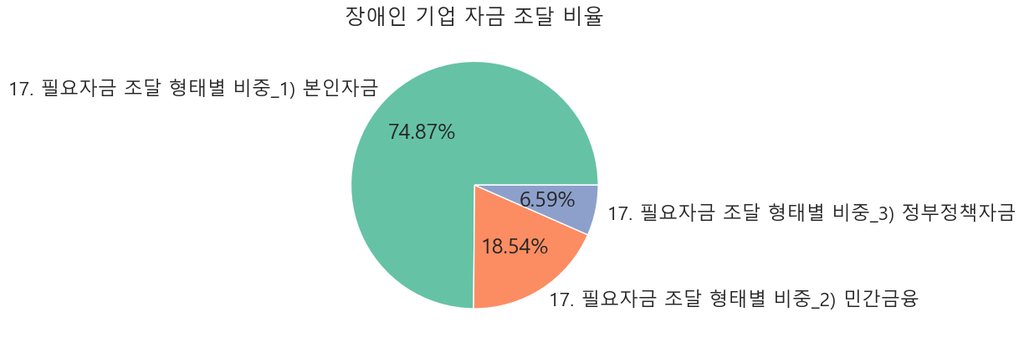

```python
columns = ['17. 필요자금 조달 형태별 비중_1) 본인자금', '17. 필요자금 조달 형태별 비중_2) 민간금융', '17. 필요자금 조달 형태별 비중_3) 정부정책자금']

ratios = df[columns].div(df[columns].sum(axis=1), axis=0) * 100

plt.pie(ratios.mean(), labels=columns, autopct='%1.2f%%')
plt.title('장애인 기업 자금 조달 비율')
plt.show()
```

### 장애인 기업의 주요 생산품 또는 서비스 분석

```python
print(df['5-1) 주요 생산품 또는 서비스(용역 등)'].value_counts(dropna=False))

print('..............................................')

print(df['5-2) 주요 생산품 또는 서비스(용역 등)의 형태'].value_counts(dropna=False))
```

```
전기공사                            61
병의원                             38
음식점                             28
건설업                             28
부동산 중개                          25
                                ..
전단.리플렛.현수막.간판.안내판 (인쇄물.옥외광고)     1
MRI & CT 유지보수                    1
수입                               1
포장재 파우치                          1
PCB CAM 소프트웨어 개발                 1
Name: 5-1) 주요 생산품 또는 서비스(용역 등), Length: 3883, dtype: int64
..............................................
5    1846
4    1118
1     915
6     663
2     476
3      63
Name: 5-2) 주요 생산품 또는 서비스(용역 등)의 형태, dtype: int64
```

```python
df['5-2) 주요 생산품 또는 서비스(용역 등)의 형태'].value_counts(normalize=True)
```

```
5    0.363314
4    0.220035
1    0.180083
6    0.130486
2    0.093682
3    0.012399
Name: 5-2) 주요 생산품 또는 서비스(용역 등)의 형태, dtype: float64
```

용역 등의 서비스인 5가 가장 많았으며 판매 및 유통인 4가 그 다음으로 많았음 완제품 (1)은 3번째로 가장 많았으며 그 후로는 공사 및 건설(6), 부품 등의 중간제품(2), 원자재(3) 순으로 많았음

용역 등의 서비스와 판매 및 유통이 절반을 넘게 차지하고 있기 때문에 제안한 정책이 도움이 많이 될 것임을 알 수 있음

### 장애인 기업 채용 분석

#### 2020년 채용 인원 및 2021년 신규 채용 계획 분석

```python
채용lst=[col for col in df.columns if col.startswith('15. 2020년')]
채용lst
```

```
['15. 2020년 채용 인원 및 2021년 신규 채용 계획 인원_(1) 2020년 채용인원_1) 장애인',
 '15. 2020년 채용 인원 및 2021년 신규 채용 계획 인원_(1) 2020년 채용인원_2) 비장애인',
 '15. 2020년 채용 인원 및 2021년 신규 채용 계획 인원_(1) 2020년 채용인원_합계',
 '15. 2020년 채용 인원 및 2021년 신규 채용 계획 인원_(2) 2021년 신규채용 계획 인원_1) 장애인',
 '15. 2020년 채용 인원 및 2021년 신규 채용 계획 인원_(2) 2021년 신규채용 계획 인원_2) 비장애인',
 '15. 2020년 채용 인원 및 2021년 신규 채용 계획 인원_(2) 2021년 신규채용 계획 인원_3) 구분없이 채용',
 '15. 2020년 채용 인원 및 2021년 신규 채용 계획 인원_(2) 2021년 신규채용 계획 인원_합계']
```

```python
df[채용lst].mean()
```

```
15. 2020년 채용 인원 및 2021년 신규 채용 계획 인원_(1) 2020년 채용인원_1) 장애인              0.086652
15. 2020년 채용 인원 및 2021년 신규 채용 계획 인원_(1) 2020년 채용인원_2) 비장애인             0.711312
15. 2020년 채용 인원 및 2021년 신규 채용 계획 인원_(1) 2020년 채용인원_합계                  0.797964
15. 2020년 채용 인원 및 2021년 신규 채용 계획 인원_(2) 2021년 신규채용 계획 인원_1) 장애인        0.074434
15. 2020년 채용 인원 및 2021년 신규 채용 계획 인원_(2) 2021년 신규채용 계획 인원_2) 비장애인       0.621719
15. 2020년 채용 인원 및 2021년 신규 채용 계획 인원_(2) 2021년 신규채용 계획 인원_3) 구분없이 채용    0.140498
15. 2020년 채용 인원 및 2021년 신규 채용 계획 인원_(2) 2021년 신규채용 계획 인원_합계            0.836652
dtype: float64
```

장애인과 비장애인을 합쳐도 평균 한 명이 되지 않음

```python
df['15. 2020년 채용 인원 및 2021년 신규 채용 계획 인원_(2) 2021년 신규채용 계획 인원_1) 장애인'].value_counts(normalize=True)
```

```
0      0.971493
1      0.017873
2      0.005430
3      0.002489
5      0.000905
4      0.000905
8      0.000226
100    0.000226
15     0.000226
10     0.000226
Name: 15. 2020년 채용 인원 및 2021년 신규 채용 계획 인원_(2) 2021년 신규채용 계획 인원_1) 장애인, dtype: float64
```

장애인 채용 계획 없는 기업이 전체 장애인 기업의 약 97%임

```python
df['15. 2020년 채용 인원 및 2021년 신규 채용 계획 인원_(1) 2020년 채용인원_1) 장애인'].value_counts(normalize=True)
```

```
0      0.966063
1      0.025113
2      0.004299
3      0.001584
5      0.000679
9      0.000452
10     0.000452
6      0.000452
29     0.000226
100    0.000226
15     0.000226
4      0.000226
Name: 15. 2020년 채용 인원 및 2021년 신규 채용 계획 인원_(1) 2020년 채용인원_1) 장애인, dtype: float64
```

2020년에 장애인을 채용하지 않은 기업이 전체 장애인 기업의 약 96%임

#### 2021년 신규채용 계획이 없는 이유 분석

```python
df['15-1. 2021년 신규채용 계획이 없는 이유'].value_counts()
```

```
1    1959
2    1257
4      60
5      31
3      25
Name: 15-1. 2021년 신규채용 계획이 없는 이유, dtype: int64
```

```python
df['15-1. 2021년 신규채용 계획이 없는 이유'].value_counts(normalize=True)
```

```
1    0.587935
2    0.377251
4    0.018007
5    0.009304
3    0.007503
Name: 15-1. 2021년 신규채용 계획이 없는 이유, dtype: float64
```

순서대로\ 인력이 충분하여 채용할 필요가 없어서(1), 당사 사정상 채용할 여건이 되지 않아서(인건비 부담 등)(2), 지원하는 사람이 없어서(4), 기타(5), 필요한 인재를 채용하기 위한 정보가 없기 때문에(3)

인력이 충분한 기업을 제외하고 신규채용 계획이 없는 이유의 대부분은 인건비 부담 등으로 채용할 여건이 되지 않아서임

모든 장애인 기업이 2021년 채용 예정인원 및 2020년 채용 인원 평균 1명이 되지 않을 정도로 상황이 좋지 않음을 알 수 있음\ 또한, 그 중에서도 장애인 채용은 없는 기업들이 96% 이상임\ → 장애인 채용 독려 필요

### 장애인기업 확인서 관련 분석

#### 장애인기업 확인서 발급 여부 분석

```python
df['31. 장애인기업 확인서 발급 여부'].value_counts(normalize=True)
```

```
3    0.374729
4    0.362330
1    0.248179
2    0.014761
Name: 31. 장애인기업 확인서 발급 여부, dtype: float64
```

순서대로\ 발급받지 않음(3) - 확인서 자체를 모름(4) - 발급받음(1) - 발급받았으나 기간이 만료됨(2)

#### 장애인기업 확인서 발급 여부 시각화

1. 발급받음
2. 발급받았으나 기간이 만료됨
3. 발급받지 않음
4. 확인서 자체를 모름

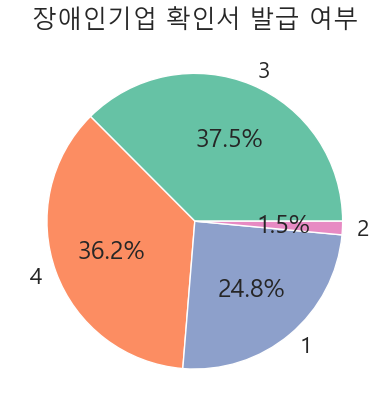

```python
plt.pie(df['31. 장애인기업 확인서 발급 여부'].value_counts(normalize=True).values, labels=df['31. 장애인기업 확인서 발급 여부'].value_counts(normalize=True).index, autopct='%1.1f%%')
plt.title('장애인기업 확인서 발급 여부')
plt.show()
```

#### 장애인기업 확인서 발급 계획 유무 분석

- 1이 있다, 2가 없다

```python
df['31-1. 장애인기업 확인서 발급 계획 유무'].value_counts(normalize=True, dropna=False)
```

```
2.0    0.508364
NaN    0.247589
1.0    0.244046
Name: 31-1. 장애인기업 확인서 발급 계획 유무, dtype: float64
```

```python
df['31-1. 장애인기업 확인서 발급 계획 유무'].value_counts(normalize=True)
```

```
2    0.675647
1    0.324353
Name: 31-1. 장애인기업 확인서 발급 계획 유무, dtype: float64
```

발급계획 없는 기업이 더 많음, NaN값은 이미 발급받은 기업임

#### 장애인기업 확인서를 발급받지 않은 이유 분석

```python
df['31-2. 장애인기업 확인서를 발급받지 않은 이유'].value_counts(normalize=True)
```

```
1    0.758983
2    0.160586
3    0.080431
Name: 31-2. 장애인기업 확인서를 발급받지 않은 이유, dtype: float64
```

확인서 발급 필요성을 못느껴서가 75%임, 절차를 몰라서 16%, 기타 8%

유효한 장애인기업 확인서를 가지고 있는 장애인 기업이 25%밖에 안됨\ 또한 발급 계획이 없는 기업이 더 많으며 확인서 발급 필요성을 못느낀 기업이 발급받지 않은 기업 중 75%임\ → 장애인기업 확인서의 발급 이유를 만들 수 있는 정책 필요

## 지원 제도 인지 여부, 이용여부, 도움정도 분석

#### 지원 제도 인지 여부 분석

```python
인지여부lst
```

```
['32. 정부 기업활동 지원 정책 _1) 금융 지원 제도(인지 여부)',
 '32. 정부 기업활동 지원 정책 _2) 인력 지원 제도(인지 여부)',
 '32. 정부 기업활동 지원 정책 _4) 기술 지원 제도(인지 여부)',
 '32. 정부 기업활동 지원 정책 _5) 판로 지원 제도(인지 여부)',
 '32. 정부 기업활동 지원 정책 _6) 정보화 지원 제도(인지 여부)',
 '32. 정부 기업활동 지원 정책 _7) 수출 지원 제도(인지 여부)',
 '32. 정부 기업활동 지원 정책 _8) 사업전환 및 (재)창업지원 제도(인지 여부)',
 '32. 정부 기업활동 지원 정책 _3) 세제 지원 제도.(인지 여부)']
```

```python
df[인지여부lst].mean()
```

```
32. 정부 기업활동 지원 정책 _1) 금융 지원 제도(인지 여부)             0.453848
32. 정부 기업활동 지원 정책 _2) 인력 지원 제도(인지 여부)             0.350718
32. 정부 기업활동 지원 정책 _4) 기술 지원 제도(인지 여부)             0.230270
32. 정부 기업활동 지원 정책 _5) 판로 지원 제도(인지 여부)             0.224562
32. 정부 기업활동 지원 정책 _6) 정보화 지원 제도(인지 여부)            0.196024
32. 정부 기업활동 지원 정책 _7) 수출 지원 제도(인지 여부)             0.178705
32. 정부 기업활동 지원 정책 _8) 사업전환 및 (재)창업지원 제도(인지 여부)    0.168471
32. 정부 기업활동 지원 정책 _3) 세제 지원 제도.(인지 여부)            0.344814
dtype: float64
```

정부의 지원 정책들 중 인지 여부가 모두 50% 이하임\ 특히 사업전환 및 (재)창업지원 제도, 정보화 지원 제도, 수출 지원 제도의 인지여부는 20% 이하임

#### 각종 지원 제도 인지 여부 시각화

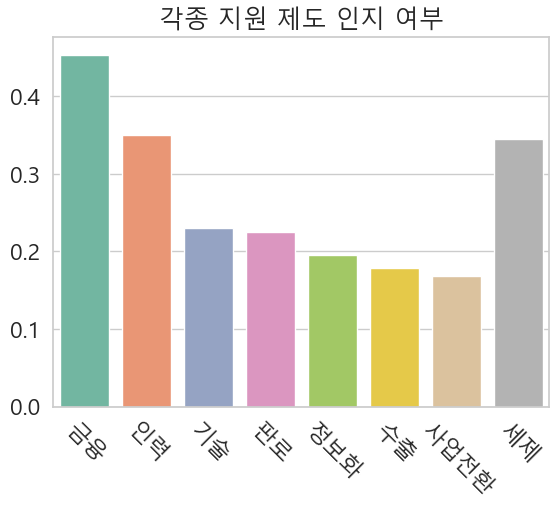

```python
sns.barplot(x=인지여부lst, y=df[인지여부lst].mean())
plt.xticks(ticks=[0,1,2,3,4,5,6,7], labels=['금융', '인력', '기술','판로','정보화','수출','사업전환', '세제'], rotation=-45)
plt.title('각종 지원 제도 인지 여부')
plt.show()
```

#### 지원 제도 이용여부 분석

```python
이용여부lst
```

```
['32. 정부 기업활동 지원 정책 _1) 금융 지원 제도(이용 여부)',
 '32. 정부 기업활동 지원 정책 _2) 인력 지원 제도(이용 여부)',
 '32. 정부 기업활동 지원 정책 _4) 기술 지원 제도(이용 여부)',
 '32. 정부 기업활동 지원 정책 _5) 판로 지원 제도(이용 여부)',
 '32. 정부 기업활동 지원 정책 _6) 정보화 지원 제도(이용 여부)',
 '32. 정부 기업활동 지원 정책 _7) 수출 지원 제도(이용 여부)',
 '32. 정부 기업활동 지원 정책 _8) 사업전환 및 (재)창업지원 제도(이용 여부)',
 '32. 정부 기업활동 지원 정책 _3) 세제 지원 제도.(이용 여부)']
```

```python
df[이용여부lst].mean()
```

```
32. 정부 기업활동 지원 정책 _1) 금융 지원 제도(이용 여부)             0.718953
32. 정부 기업활동 지원 정책 _2) 인력 지원 제도(이용 여부)             0.753789
32. 정부 기업활동 지원 정책 _4) 기술 지원 제도(이용 여부)             0.802598
32. 정부 기업활동 지원 정책 _5) 판로 지원 제도(이용 여부)             0.819327
32. 정부 기업활동 지원 정책 _6) 정보화 지원 제도(이용 여부)            0.822082
32. 정부 기업활동 지원 정책 _7) 수출 지원 제도(이용 여부)             0.836450
32. 정부 기업활동 지원 정책 _8) 사업전환 및 (재)창업지원 제도(이용 여부)    0.838418
32. 정부 기업활동 지원 정책 _3) 세제 지원 제도.(이용 여부)            0.768156
dtype: float64
```

정부의 지원 정책들의 이용 여부는 인지 여부 보다 높음\ 정책들을 정확히 인지하지 못하고 부분적으로 이용하는 경우가 많음

장애인 기업들이 정부의 지원 정책들을 이용하고 있지만, 정책들을 인지하고 있다고 판단하고 있지 않음\ 더 많은 지원 정책을 인지할 수 있도록 만들어야 할 필요가 있음. → 지원 정책 시행시 정확한 홍보가 필요함

#### 각종 지원 제도 이용 여부 시각화

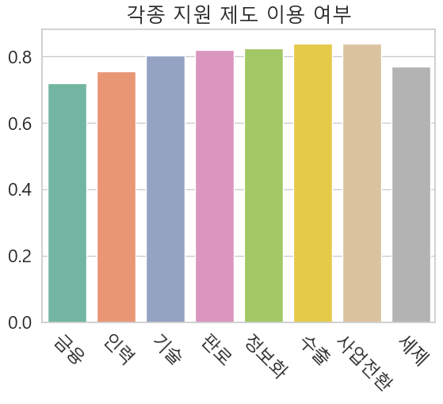

```python
sns.barplot(x=이용여부lst, y=df[이용여부lst].mean())
plt.xticks(ticks=[0,1,2,3,4,5,6,7], labels=['금융', '인력', '기술','판로','정보화','수출','사업전환', '세제'], rotation=-45)
plt.title('각종 지원 제도 이용 여부')
plt.show()
```

#### 지원 제도 도움정도 분석

- 1이 전혀 도움 안됨, 5가 매우 도움이 됨

```python
도움정도lst=[col for col in df.columns if col.endswith('제도(도움정도)')]
도움정도lst.append('32. 정부 기업활동 지원 정책 _3) 세제 지원 제도.(도움정도)')
도움정도lst
```

```
['32. 정부 기업활동 지원 정책 _1) 금융 지원 제도(도움정도)',
 '32. 정부 기업활동 지원 정책 _2) 인력 지원 제도(도움정도)',
 '32. 정부 기업활동 지원 정책 _4) 기술 지원 제도(도움정도)',
 '32. 정부 기업활동 지원 정책 _5) 판로 지원 제도(도움정도)',
 '32. 정부 기업활동 지원 정책 _6) 정보화 지원 제도(도움정도)',
 '32. 정부 기업활동 지원 정책 _7) 수출 지원 제도(도움정도)',
 '32. 정부 기업활동 지원 정책 _8) 사업전환 및 (재)창업지원 제도(도움정도)',
 '32. 정부 기업활동 지원 정책 _3) 세제 지원 제도.(도움정도)']
```

```python
df[도움정도lst].mean()
```

```
32. 정부 기업활동 지원 정책 _1) 금융 지원 제도(도움정도)             3.867391
32. 정부 기업활동 지원 정책 _2) 인력 지원 제도(도움정도)             3.747646
32. 정부 기업활동 지원 정책 _4) 기술 지원 제도(도움정도)             3.730539
32. 정부 기업활동 지원 정책 _5) 판로 지원 제도(도움정도)             3.937220
32. 정부 기업활동 지원 정책 _6) 정보화 지원 제도(도움정도)            3.402174
32. 정부 기업활동 지원 정책 _7) 수출 지원 제도(도움정도)             3.545455
32. 정부 기업활동 지원 정책 _8) 사업전환 및 (재)창업지원 제도(도움정도)    3.228571
32. 정부 기업활동 지원 정책 _3) 세제 지원 제도.(도움정도)            3.726655
dtype: float64
```

판로지원제의 도움 정도가 가장 높음

사업전환 및 (재)창업지원 제도와 정보화 지원 제도보다 금융, 인력, 기술, 판로, 세제 등 직접적인 도움을 주는 정책이 도움을 많이 주는 것을 알 수 있음\ 대부분 4점을 넘지 않는 것으로 보아 더 실질적으로, 직접적으로 도움을 주는 정책의 필요성을 보여줌

#### 각종 지원 제도 도움 정도 시각화

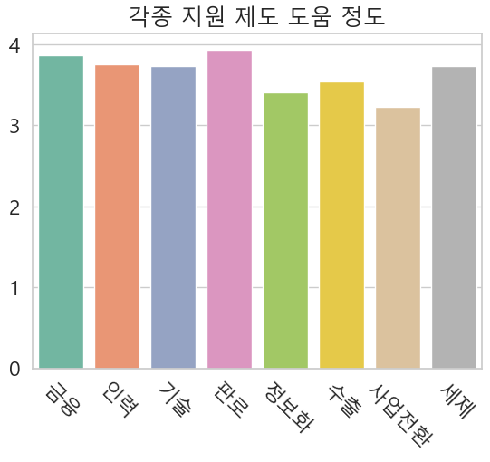

```python
sns.barplot(x=도움정도lst, y=df[도움정도lst].mean())
plt.xticks(ticks=[0,1,2,3,4,5,6,7], labels=['금융', '인력', '기술','판로','정보화','수출','사업전환', '세제'], rotation=-45)
plt.title('각종 지원 제도 도움 정도')
plt.show()
```

#### 향후 필요한 장애인기업 활동 지원정책 분석

- 1이 매우 불필요함, 5가 매우 필요함

```python
향후정책lst=[col for col in df.columns if col.startswith('34. 향후 필요한 장애인기업 활동 지원정책')]
```

```python
df[향후정책lst].mean()
```

```
34. 향후 필요한 장애인기업 활동 지원정책_1) 금융 지원 제도             4.060618
34. 향후 필요한 장애인기업 활동 지원정책_2) 인력 지원 제도             3.715017
34. 향후 필요한 장애인기업 활동 지원정책_3) 세제 지원 제도             4.121826
34. 향후 필요한 장애인기업 활동 지원정책_4) 기술 지원 제도             3.488487
34. 향후 필요한 장애인기업 활동 지원정책_5) 판로 지원 제도             3.717772
34. 향후 필요한 장애인기업 활동 지원정책_6) 정보화 지원 제도            3.466444
34. 향후 필요한 장애인기업 활동 지원정책_7) 수출 지원 제도             3.029522
34. 향후 필요한 장애인기업 활동 지원정책_8) 사업전환 및 (재)창업지원 제도    3.149577
34. 향후 필요한 장애인기업 활동 지원정책_9) 교육 및 컨설팅             3.290888
dtype: float64
```

향후 필요한 정책에는 금융지원제도, 세제 지원 제도에 대한게 가장 높았음

# 가설1.

#### **장애인 기업들은 일반 다른 기업들에 비해 기업경쟁력이 떨어질 것이고 기술 발전에서 취약함을 보일 것이다.**

### 장애인 기업 경쟁기업 대비 수준 점수 분석

- 장애인 기업 자체 평가
- 1이 매우 열등함, 5가 매우 우수함을 의미

#### 경쟁기업 대비 수준열 리스트 생성

```python
경쟁수준lst=[col for col in df.columns if col.startswith('20.')]
```

```python
경쟁수준lst
```

```
['20. 경쟁기업 대비 수준_1) 생산능력',
 '20. 경쟁기업 대비 수준_2) 가격경쟁력',
 '20. 경쟁기업 대비 수준_3) 기술경쟁력',
 '20. 경쟁기업 대비 수준_4) 품질경쟁력',
 '20. 경쟁기업 대비 수준_5) 영업/마케팅 역량',
 '20. 경쟁기업 대비 수준_6) 시장점유율',
 '20. 경쟁기업 대비 수준_7) 거래 신용도',
 '20. 경쟁기업 대비 수준_8) 재정적 기반',
 '20. 경쟁기업 대비 수준_9) 고객만족도',
 '20. 경쟁기업 대비 수준_10) 전반적 경쟁력']
```

#### 장애인 기업 경쟁기업 대비 수준 평균 점수 확인

```python
df[경쟁수준lst].mean()
```

```
20. 경쟁기업 대비 수준_1) 생산능력         3.332218
20. 경쟁기업 대비 수준_2) 가격경쟁력        3.311553
20. 경쟁기업 대비 수준_3) 기술경쟁력        3.524897
20. 경쟁기업 대비 수준_4) 품질경쟁력        3.567998
20. 경쟁기업 대비 수준_5) 영업/마케팅 역량    3.128912
20. 경쟁기업 대비 수준_6) 시장점유율        3.094470
20. 경쟁기업 대비 수준_7) 거래 신용도       3.603228
20. 경쟁기업 대비 수준_8) 재정적 기반       3.119465
20. 경쟁기업 대비 수준_9) 고객만족도        3.609526
20. 경쟁기업 대비 수준_10) 전반적 경쟁력     3.355245
dtype: float64
```

전체적으로 보았을 때 경쟁기업 대비 수준을 평균 이상이라고 평가함\ 특히 고객만족도, 거래 신용도, 품질경쟁력, 기술경쟁력을 높이 평가함\ 자체 평가 점수가 낮은 분야는 시장점유율,재정적 기반, 영업/마케팅 역량임

가설과는 다르게 장애인기업 자체평가는 경쟁기업 대비 수준이 평균 이상이라고 평가함

### 장애인 기업 애로사항 분석

#### 경영상 애로사항 1순위 분석

```python
df['22. 경영상 애로사항_1순위'].value_counts(normalize=True)
```

```
1    0.384570
3    0.257823
2    0.194056
8    0.061799
7    0.047235
6    0.033655
5    0.015154
4    0.005708
Name: 22. 경영상 애로사항_1순위, dtype: float64
```

순서대로 자금 조달(1), 판로 확보/마케팅(3), 인력 확보/관리(2), 각종 행정 규제/절차(8), 기술개발(7), 수출(6)\ 주요 경영상 애로사항은 자금 조달, 판로 확보 및 마케팅, 인력 확보 및 관리임

#### 경영상 애로사항 2순위 분석

```python
df['22. 경영상 애로사항_2순위'].value_counts(normalize=True)
```

```
3    0.321429
2    0.279464
1    0.185714
6    0.098214
5    0.070536
7    0.026488
4    0.018155
Name: 22. 경영상 애로사항_2순위, dtype: float64
```

경영상 애로사항 2순위로는 판로 확보/마케팅, 인력 확보/관리, 자금 조달 순으로 응답함

경영상 애로사항 분석 결과 자금 조달이 가장 큰 문제로 뽑혔고, 그 다음으로 판로 확보 및 마케팅, 인력 확보 및 관리 등이 뽑힘

### 장애인 기업 자금 조달 애로사항 분석

#### 자금 조달 애로사항 1순위 분석

```python
df['23. 자금조달 애로사항_1순위'].value_counts(normalize=True)
```

```
6    0.444204
1    0.217674
3    0.120646
2    0.087975
4    0.087975
5    0.024405
7    0.017123
Name: 23. 자금조달 애로사항_1순위, dtype: float64
```

순서대로 해당사항 없음(6), 대출한도의 부족(1), 고금리(3), 담보부족(2), 신용보증기준의 엄격함(4), 낮은 신용도(5), 기타(7)\ 자금 조달에 문제가 있는 기업은 대출한도의 부족과 고금리를 가장 큰 문제로 뽑음

#### 자금 조달 애로사항 2순위 분석

```python
df['23. 자금조달 애로사항_2순위'].value_counts(normalize=True)
```

```
4    0.267148
2    0.251160
1    0.199587
3    0.196493
5    0.081485
7    0.004126
Name: 23. 자금조달 애로사항_2순위, dtype: float64
```

순서대로 신용보증기준의 엄격함, 담보부족, 대출한도의 부족, 고금리, 낮은 신용도, 기타

자금 조달 주요 애로사항으로는 대출한도의 부족과 고금리, 담보부족을 뽑음

### 판로 확보/마케팅 애로사항분석

#### 판로 확보/마케팅 애로사항 1순위 분석

```python
df['25.판로 확보/마케팅 애로사항_1순위'].value_counts(normalize=True)
```

```
6    0.463885
1    0.182248
4    0.163747
2    0.080299
3    0.055304
5    0.044283
7    0.010234
Name: 25.판로 확보/마케팅 애로사항_1순위, dtype: float64
```

순서대로 해당사항 없음(6), 시장(소비자)조사 및 관련 정보의 제공(1), 홍보 및 광고 관련 지원(4), 신제품 기획 및 개발 기획 지원(2), 마케팅 역량 제고를 위한 교육지원(3), 공동물류시설 및 공동판매망 설치 등 인프라 지원(5), 기타(7)

#### 판로 확보/마케팅 애로사항 2순위 분석

```python
df['25.판로 확보/마케팅 애로사항_2순위'].value_counts(normalize=True)
```

```
4    0.318304
1    0.216855
3    0.190553
2    0.154589
5    0.117552
7    0.002147
Name: 25.판로 확보/마케팅 애로사항_2순위, dtype: float64
```

순서대로 홍보 및 광고 관련 지원, 시장(소비자)조사 및 관련 정보의 제공, 마케팅 역량 제고를 위한 교육지원, 신제품 기획 및 개발 기획 지원, 공동물류시설, 공동판매망 설치 등 인프라 지원, 기타

장애인 기업들의 판로 확보/마케팅 관련 애로사항으로는 시장조사 및 관련 정보가 가장 부족한 것으로 응답했고, 그 뒤로 각종 홍보 지원 요청들이 뒤따름

### 인력 확보/관리 애로사항 분석

#### 인력 확보/관리 애로사항 1순위 분석

```python
df['24. 인력 확보/관리 애로사항_1순위'].value_counts(normalize=True)
```

```
7    0.371384
3    0.270419
1    0.161189
2    0.120842
4    0.053139
5    0.015154
6    0.006888
8    0.000984
Name: 24. 인력 확보/관리 애로사항_1순위, dtype: float64
```

순서대로 해당사항 없음(7), 높은 인건비(3), 전문인력(기술자, 연구원 등) 구인난(1), 일반 인력 구인난(2), 잦은 이직(4), 복리후생(연금, 복지시설 등)(5), 교육훈련(6), 기타(8)

인력확보 애로사항 1순위의 해당 사항들 중 가장 높은 것은 인건비가 문제로 나옴\ 인력 관련도 결국 돈 문제

#### 인력 확보/관리 애로사항 2순위 분석

```python
df['24. 인력 확보/관리 애로사항_2순위'].value_counts(normalize=True)
```

```
3    0.290768
4    0.273943
2    0.195427
1    0.115617
5    0.087575
6    0.035375
8    0.001294
Name: 24. 인력 확보/관리 애로사항_2순위, dtype: float64
```

순서대로 높은 인건비, 잦은 이직, 일반 인력 구인난, 전문인력(기술자, 연구원 등 구인난), 복리후생(연금, 복지시설 등), 교육훈련, 기타

2순위에서도 또한 높은 인건비가 가장 큰 문제이고 잦은 이직도 2순위에 올랐음

### 기술개발 애로사항 분석

#### 기술개발 애로사항 1순위 분석

```python
df['27. 기술개발 애로사항_1순위'].value_counts(normalize=True)
```

```
7    0.771502
1    0.101752
2    0.054714
4    0.024208
5    0.016729
3    0.016532
6    0.014564
Name: 27. 기술개발 애로사항_1순위, dtype: float64
```

순서대로 해당사항 없음(7), 기술개발 자금의 부족(1), 개발인력 확보 곤란(2), 기술개발 경험 부족(4), 기술에 대한 정보 부족(5), 개발 소요기간(3), 기술개발 기획능력 부족(6)

해당없음이 가장 많고 다음이 바로 자금 조달 문제임\ 기술개발에서도 자금 조달 관련 문제가 생김을 알 수 있음

#### 기술개발 애로사항 2순위 분석

```python
df['27. 기술개발 애로사항_2순위'].value_counts(normalize=True)
```

```
2    0.338372
3    0.159302
4    0.138372
1    0.131395
5    0.122093
6    0.110465
Name: 27. 기술개발 애로사항_2순위, dtype: float64
```

순서대로 개발인력 확보 곤란, 개발 소요기간, 기술개발 경험 부족, 기술개발 자금의 부족, 기술에 대한 정보 부족, 기술개발 기획능력 부족

### 가설 1 분석 결과

1. 가설과는 다르게 장애인기업 자체평가는 경쟁기업 대비 수준이 평균 이상이라고 평가함
2. 경영상 애로사항 분석 결과 자금 조달이 가장 큰 문제로 뽑혔고, 그 다음으로 판로 확보 및 마케팅, 인력 확보 및 관리 등이 뽑힘
3. 자금 조달 애로사항 분석 결과 대출한도의 부족과 고금리, 담보부족이 가장 큰 문제임
4. 판로 확보/마케팅, 인력 확보 및 관리, 기술개발 등의 애로사항들은 대부분 자금 조달에서 파생되는 애로사항들임

결론 : 장애인 기업의 자금 조달 문제를 해결할 정책이 필요하다.

# 가설2.

#### **장애인 고용비율이 높을 수록 기업 경쟁력이 낮을 것이다.**

### 장애인 종사자 비율 25 이상 여부에 따른 총 매출액, 평균 영업이익 분석

```python
df.groupby(['장애인 종사자 비율 25 이상'])[['16. 매출액 및 영업이익 현황(2020년)_1) 연간 총 매출액','16. 매출액 및 영업이익 현황(2020년)_2) 영업이익']].mean()
```

| 장애인 종사자 비율 25 이상 | 16. 매출액 및 영업이익 현황(2020년)_1) 연간 총 매출액 | 16. 매출액 및 영업이익 현황(2020년)_2) 영업이익 |
| --- | --- | --- |
| 0 | 2398.561832 | 142.723664 |
| 1 | 579.934012 | 38.724236 |

### 장애인 종사자 비율 25 이상 여부에 따른 자금사정 분석

- 1이 매우 나빴음, 5가 매우 좋았음

```python
df.groupby(['장애인 종사자 비율 25 이상'])[['18. 2020년 자금사정']].mean()
```

| 장애인 종사자 비율 25 이상 | 18. 2020년 자금사정 |
| --- | --- |
| 0 | 2.415080 |
| 1 | 2.075764 |

장애인 종사자 비율이 높은 기업의 자금사정이 더 좋지 않음

### 장애인 종사자 비율 25이상 여부에 따른 경쟁수준 분석

```python
df.groupby(['장애인 종사자 비율 25 이상'])[경쟁수준lst].mean()
```

| 장애인 종사자 비율 25 이상 | 20. 경쟁기업 대비 수준_1) 생산능력 | 20. 경쟁기업 대비 수준_2) 가격경쟁력 | 20. 경쟁기업 대비 수준_3) 기술경쟁력 | 20. 경쟁기업 대비 수준_4) 품질경쟁력 | 20. 경쟁기업 대비 수준_5) 영업/마케팅 역량 | 20. 경쟁기업 대비 수준_6) 시장점유율 | 20. 경쟁기업 대비 수준_7) 거래 신용도 | 20. 경쟁기업 대비 수준_8) 재정적 기반 | 20. 경쟁기업 대비 수준_9) 고객만족도 | 20. 경쟁기업 대비 수준_10) 전반적 경쟁력 |
| --- | --- | --- | --- | --- | --- | --- | --- | --- | --- | --- |
| 0 | 3.455826 | 3.387281 | 3.626809 | 3.671363 | 3.265804 | 3.226961 | 3.744097 | 3.268850 | 3.713252 | 3.499238 |
| 1 | 3.200000 | 3.230550 | 3.415886 | 3.457434 | 2.982485 | 2.952749 | 3.452546 | 2.959674 | 3.498574 | 3.201222 |

전반적으로 장애인 종사자 비율이 25%이상인 기업이 그렇지 않은 기업보다 0.2점 정도 더 낮음

### 장애인 종사자 비율 25이상 여부에 따른 인지여부 비율 분석

```python
df.groupby(['장애인 종사자 비율 25 이상'])[인지여부lst].mean()
```

| 장애인 종사자 비율 25 이상 | 32. 정부 기업활동 지원 정책 _1) 금융 지원 제도(인지 여부) | 32. 정부 기업활동 지원 정책 _2) 인력 지원 제도(인지 여부) | 32. 정부 기업활동 지원 정책 _4) 기술 지원 제도(인지 여부) | 32. 정부 기업활동 지원 정책 _5) 판로 지원 제도(인지 여부) | 32. 정부 기업활동 지원 정책 _6) 정보화 지원 제도(인지 여부) | 32. 정부 기업활동 지원 정책 _7) 수출 지원 제도(인지 여부) | 32. 정부 기업활동 지원 정책 _8) 사업전환 및 (재)창업지원 제도(인지 여부) | 32. 정부 기업활동 지원 정책 _3) 세제 지원 제도.(인지 여부) |
| --- | --- | --- | --- | --- | --- | --- | --- | --- |
| 0 | 0.504570 | 0.447068 | 0.286748 | 0.276085 | 0.239528 | 0.214775 | 0.190784 | 0.414699 |
| 1 | 0.399593 | 0.247658 | 0.169857 | 0.169450 | 0.149491 | 0.140122 | 0.144603 | 0.270061 |

장애인 종사자 비율이 높은 기업이 장애인기업 관련 지원 정책 인지여부가 낮음

### 장애인 종사자 비율 25이상 여부에 따른 장애인기업 확인서 발급 여부 분석

```python
df.groupby(['장애인 종사자 비율 25 이상', '31. 장애인기업 확인서 발급 여부' ])[['31. 장애인기업 확인서 발급 여부']].count()
```

| 장애인 종사자 비율 25 이상 | 31. 장애인기업 확인서 발급 여부 | 31. 장애인기업 확인서 발급 여부 |
| --- | --- | --- |
| 0 | 1 | 712 |
|  | 2 | 50 |
|  | 3 | 957 |
|  | 4 | 907 |
| 1 | 1 | 549 |
|  | 2 | 25 |
|  | 3 | 947 |
|  | 4 | 934 |

순서대로\ 장애인 종사자 비율에 관계 없이 발급받지 않음(3) - 확인서 자체를 모름(4) - 발급받음(1) - 발급받았으나 기간이 만료됨(2)

### 가설 2 분석 결과

1. 매출액, 평균 영업이익, 자금사정, 인지여부 모두 장애인 종사자 비율이 25%이상인 기업이 낮았음
2. 또한 장애인 종사자 비율이 높은 기업이 장애인기업 관련 지원 정책 인지여부가 낮음

결론 : 장애인 종사자 비율이 높은 기업이 그렇지 않은 기업보다 여러움이 많다.\ 장애인기업 지원 정책의 홍보가 필요하다는 것을 알 수 있다.\ 장애인기업확인서를 발급한 기업만 입점할 수 있는 사이트를 개설한다면 매출액 개선은 물론 평균 영업이익, 자금 사정 또한 증가할 것이라고 기대된다. 또한 장애인기업확인서를 발급 받을 기업이 증가하고 장애인 기업 지원 정책에 대한 관심과 혜택을 받을 수 있는 기업의 수가 늘어날 것이다.

# 가설3.

#### **장애인기업은 일반 기업들보다 혁신형기업의 비율이 적을 것이다.**

### 혁신형 기업 분석

#### 이노비즈기업 분석

```python
print(df['2. 혁신형 기업 유형_1) 이노비즈기업'].value_counts(dropna=False))
```

```
0    4780
1     301
Name: 2. 혁신형 기업 유형_1) 이노비즈기업, dtype: int64
```

#### 벤처기업 분석

```python
print(df['2. 혁신형 기업 유형_2) 벤처기업'].value_counts(normalize=True))
```

```
0    0.94509
1    0.05491
Name: 2. 혁신형 기업 유형_2) 벤처기업, dtype: float64
```

#### 경영혁신기업 분석

```python
print(df['2. 혁신형 기업 유형_3) 경영혁신기업'].value_counts(normalize=True))
```

```
0    0.955717
1    0.044283
Name: 2. 혁신형 기업 유형_3) 경영혁신기업, dtype: float64
```

#### 장애인 기업 중 혁신기업 비율 확인

```python
혁신기업lst = ['2. 혁신형 기업 유형_1) 이노비즈기업','2. 혁신형 기업 유형_2) 벤처기업', '2. 혁신형 기업 유형_3) 경영혁신기업', '혁신형 기업 미해당']
```

```python
df[혁신기업lst].mean()
```

```
2. 혁신형 기업 유형_1) 이노비즈기업    0.059240
2. 혁신형 기업 유형_2) 벤처기업      0.054910
2. 혁신형 기업 유형_3) 경영혁신기업    0.044283
혁신형 기업 미해당                0.882897
dtype: float64
```

장애인 기업 중 각 혁신형 기업에 해당하는 비율은 모두 약 5%정도임\ 혁신형 기업 인증을 받지 않은 기업이 전체 장애인 기업의 약 88%임

#### 중소기업전망조사(2022년) 데이터 기업유형 분석

- 일반기업 1, 벤처/이노비스/경영혁신기업 0
- 평균 계산시 전체 중소기업의 혁신형 기업 인증 여부를 알 수 있음

```python
전망조사df['기업유형'].mean()
```

```
0.8792963388330205
```

혁신형 기업 인증을 받지 않은 기업은 전체 중소 기업의 약 88%임

#### 혁신 기업 여부 시각화

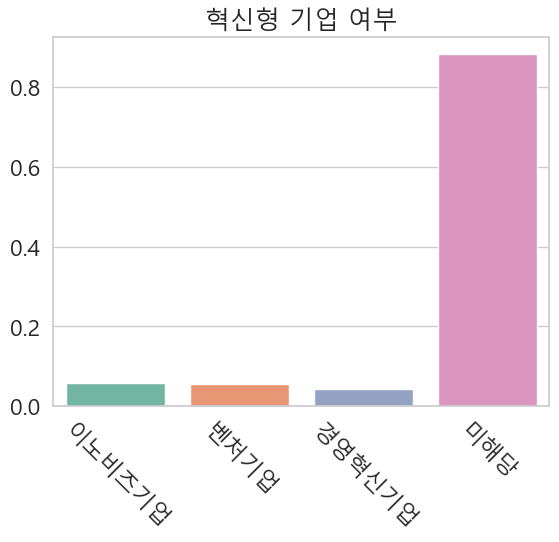

```python
sns.barplot(x=혁신기업lst, y=df[혁신기업lst].mean())
plt.xticks(ticks=[0,1,2,3], labels=['이노비즈기업', '벤처기업', '경영혁신기업','미해당'], rotation=-45)
plt.title('혁신형 기업 여부')
plt.show()
```

### 추가분석

#### 조달가점 인증 분석

```python
조달가점lst=[col for col in df.columns if col.startswith('3. 조달가점')]
조달가점lst.append('조달가점 미해당')
```

```python
조달가점lst
```

```
['3. 조달가점 인증_1) KS',
 '3. 조달가점 인증_2) 환경마크',
 '3. 조달가점 인증_3) GR',
 '3. 조달가점 인증_4) K마크',
 '3. 조달가점 인증_5) Q마크',
 '3. 조달가점 인증_6) 고효율에너지기자재',
 '조달가점 미해당']
```

```python
df[조달가점lst].mean()
```

```
3. 조달가점 인증_1) KS           0.027160
3. 조달가점 인증_2) 환경마크         0.013186
3. 조달가점 인증_3) GR           0.001181
3. 조달가점 인증_4) K마크          0.006692
3. 조달가점 인증_5) Q마크          0.004920
3. 조달가점 인증_6) 고효율에너지기자재    0.006888
조달가점 미해당                   0.960047
dtype: float64
```

대부분이 1퍼센트 미만이고 미해당 기업이 96%임

#### 조달가점 인증 여부 시각화

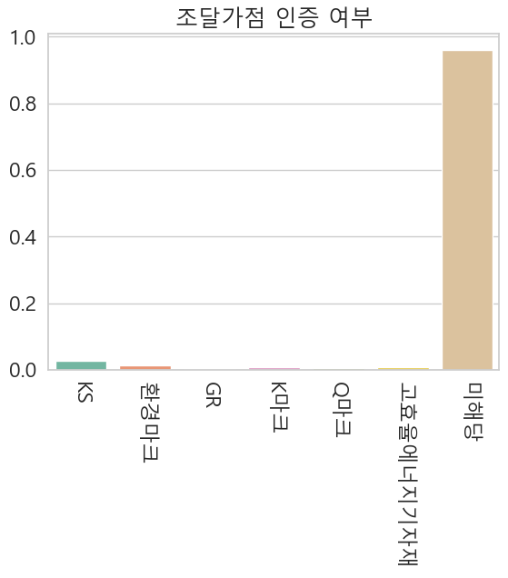

```python
sns.barplot(x=조달가점lst, y=df[조달가점lst].mean())
plt.xticks(ticks=[0,1,2,3,4,5,6], labels=['KS', '환경마크', 'GR','K마크', 'Q마크', '고효율에너지기자재', '미해당'], rotation=-90)
plt.title('조달가점 인증 여부')
plt.show()
```

```python
우선구매대상lst=[col for col in df.columns if col.startswith('4. 우선구매대상')]
우선구매대상lst
```

```
['4. 우선구매대상 기술개발제품 인증_1) NET',
 '4. 우선구매대상 기술개발제품 인증_2) NEP',
 '4. 우선구매대상 기술개발제품 인증_3) GS',
 '4. 우선구매대상 기술개발제품 인증_4) 우수조달',
 '4. 우선구매대상 기술개발제품 인증_5) 성능인증',
 '4. 우선구매대상 기술개발제품 인증_6) 녹색기술제품',
 '4. 우선구매대상 기술개발제품 인증_7) 우수조달공동상표지정물품',
 '4. 우선구매대상 기술개발제품 인증_8) 산업융합품목',
 '4. 우선구매대상 기술개발제품 인증_9) 민·관공동투자기술개발사업제품',
 '4. 우선구매대상 기술개발제품 인증_10) 성과공유기술과제제품',
 '4. 우선구매대상 기술개발제품 인증_11) ICT융합품질인증제품',
 '4. 우선구매대상 기술개발제품 인증_12) 중소기업융복합기술개발',
 '4. 우선구매대상 기술개발제품 인증_13) 산업융합적합성품목',
 '4. 우선구매대상 기술개발제품 인증_14) 우수디자인상품',
 '4. 우선구매대상 기술개발제품 인증_15) 개발선정품',
 '4. 우선구매대상 기술개발제품 인증_16) 구매조건부R&D사업을 통해 개발에 성공한 제품']
```

```python
df[우선구매대상lst].mean()
```

```
4. 우선구매대상 기술개발제품 인증_1) NET                           0.001771
4. 우선구매대상 기술개발제품 인증_2) NEP                           0.000984
4. 우선구매대상 기술개발제품 인증_3) GS                            0.003149
4. 우선구매대상 기술개발제품 인증_4) 우수조달                          0.008463
4. 우선구매대상 기술개발제품 인증_5) 성능인증                          0.007085
4. 우선구매대상 기술개발제품 인증_6) 녹색기술제품                        0.003543
4. 우선구매대상 기술개발제품 인증_7) 우수조달공동상표지정물품                  0.001574
4. 우선구매대상 기술개발제품 인증_8) 산업융합품목                        0.000984
4. 우선구매대상 기술개발제품 인증_9) 민·관공동투자기술개발사업제품               0.001378
4. 우선구매대상 기술개발제품 인증_10) 성과공유기술과제제품                   0.000590
4. 우선구매대상 기술개발제품 인증_11) ICT융합품질인증제품                  0.000394
4. 우선구매대상 기술개발제품 인증_12) 중소기업융복합기술개발                  0.001771
4. 우선구매대상 기술개발제품 인증_13) 산업융합적합성품목                    0.000197
4. 우선구매대상 기술개발제품 인증_14) 우수디자인상품                      0.005314
4. 우선구매대상 기술개발제품 인증_15) 개발선정품                        0.001968
4. 우선구매대상 기술개발제품 인증_16) 구매조건부R&D사업을 통해 개발에 성공한 제품    0.002362
dtype: float64
```

16개의 우선구매대상 기술개발제품 인증 중 1%가 넘는 것이 없음

### 가설 3 분석 결과

1. 장애인기업 중 혁신형 기업의 비율은 전체 중소기업 중 혁신형 기업의 비율과 거의 같다는 것을 알 수 있음
2. 장애인기업의 조달가점 인증, 우선구매대상 기술개발제품 인증 비율은 매우 낮은 것을 알 수 있음

결론 : 가설 3 분석 결과, 가설 1의 결론과 같이 장애인 기업의 기술력이 타 중소기업에 비해 낮지 않다고 판단할 수 있다.\ 따라서 제안한 정책을 시행한다면 장애인 기업도 경쟁력을 갖출 수 있을 것이라고 예상된다.